# Bivariate Inference

# Overview

We’ve been visually exploring relationships between two variables by creating appropriate plots to assess how the distribution of a primary outcome (response/dependent) variable changes according to the level of a predictor (explanatory/independent/covariate) variable. We can learn a lot by conducting exploratory data analysis, and if description is the goal then this is where your work can stop.

However, if you want to make conclusions or **inference** about a relationship, then formal statistical analysis techniques are needed. We start here by formally testing if relationships or associations between *two* measures exist, then later will see how additional third variables can potentially disrupt or enhance any association that you may find.

## Assignment Instructions

In this assignment you will practice **FIVE(5)** different types of bivariate analysis:

1. (Q~B) Quantitative Outcome ~ Binary Categorical Explanatory == Two-sample t-tests for a difference in means
2. (Q~C) Quantitative Outcome ~ Categorical Explanatory == ANOVA
3. (B~C) Binary Outcome ~ Categorical (or Binary) Explanatory == $\chi^{2}$ test of Association.
4. (Q~Q) Quantitative Outcome ~ Quantitative Explanatory == Correlation analysis
5. (Q~Q) Quantitative Outcome ~ Quantitative Explanatory == Linear regression analysis

For each analysis you will do the following steps:

1. State which variable (including the variable name from your codebook) will be your explanatory variable and which will be your response variable.
   - Remember, you have some variables in your codebook that can act as both categorical and quantitative.
   - Decide which of those variables makes sense to “explain” the other. Don’t just blindly pick a bunch of variables.
   - Think about the relationship among your variables, keeping in mind your original research questions. You may use gender as your categorical explanatory variable if you are struggling to find an explanatory and response relationship that makes sense.
2. Create an appropriate bivariate plot to visualize the relationship you are exploring. Summarize the relationship between the explanatory and outcome variables in short paragraph form.
3. Write the relationship you want to examine in the form of a research question.
   - State the null and alternative hypotheses as sentences.
4. Perform an appropriate statistical analysis using the full five step method as outlined in class and described below.
   - Define the parameters being tested. ($\rho$, $p_{1}$, $\mu_{1}$, $\beta_{1}$ etc)
   - Translate the null and alternative hypotheses into $H_{0}$ and $H_{A}$ with symbols.
   - State and verify assumptions of the test. Even if these assumptions are potentially violated, for the purposes of this assignment, acknowledge this limitation and continue with the prescribed analysis.
   - Conduct the analysis using your software program of choice. Make a decision whether or not to reject the null hypothesis. State your p-value.
5. Write a conclusion in context of the problem.

## Submission Instructions:

- Use the RMD or WORD to template answer the questions.
- As you complete each question
  - upload your document (word or pdf) to the assignment folder in Google Drive
  - Add your code (or SPSS Menu instructions) to HackMD to help others. If code is already there, add comments, correct or clarify the instructions, make the code generic.
  - This assignment is *not* officially peer reviewed, but allows others who may be struggling to see what you have done.
  - Everyone is encouraged to leave comments and questions on your peers’ submission.
  - You have access to a large learning community - contribute to it and use it!
- Submit the final version as a PDF to Blackboard Learn by the due date.

```r
library(knitr)
opts_chunk$set(warning=FALSE, message=FALSE)
library(dplyr)
library(ggplot2)
library(pander)
library(scales)

load("C:/Box/Data/AddHealth/addhealth_clean.Rdata")
```

# (Q~B) Two sample T-Test for Independent Groups

We would like to know, is there convincing evidence that the average BMI differs between those who have ever smoked a cigarette in their life compared to those who have never smoked?

##### Example

1. **Identify response and explanatory variables**
- Ever smoker = binary explanatory variable (variable `eversmoke_c`)
- BMI = quantitative response variable (variable `BMI`)
2. **Visualize and summarise bivariate relationship**

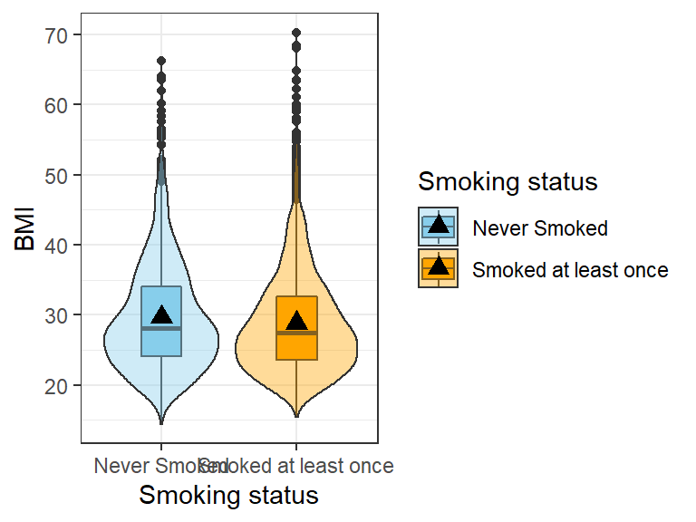

```r
plot.bmi.smoke <- addhealth %>% select(eversmoke_c, BMI) %>% na.omit()

ggplot(plot.bmi.smoke, aes(x=eversmoke_c, y=BMI, fill=eversmoke_c)) +
      geom_boxplot(width=.3) + geom_violin(alpha=.4) + theme_bw() +
      labs(x="Smoking status") +
      scale_fill_manual(values=c("skyblue", "orange"), name="Smoking status") +
      stat_summary(fun.y="mean", geom="point", size=3, pch=17,
      position=position_dodge(width=0.75))
```

```r
plot.bmi.smoke %>% group_by(eversmoke_c) %>%
              summarise(mean=mean(BMI, na.rm=TRUE),
                        sd = sd(BMI, na.rm=TRUE)) %>%
              kable()
```

| eversmoke_c | mean | sd |
| --- | --- | --- |
| Never Smoked | 29.67977 | 7.764303 |
| Smoked at least once | 28.84722 | 7.319963 |

Smokers have on average BMI of 28.8, smaller than the average BMI of non-smokers at 29.7. Non-smokers have more variation in their weights (7.8 vs 7.3lbs), but the distributions both look normal, if slightly skewed right.

3. **Write the relationship you want to examine in the form of a research question.**
- Null Hypothesis: There is no difference in the average BMI between smokers and non-smokers.
- Alternate Hypothesis: There is a difference in the average BMI between smokers and non-smokers.
4. **Perform an appropriate statistical analysis.**

```r
t.test(BMI ~ eversmoke_c, data=addhealth)
```

```
##
##  Welch Two Sample t-test
##
## data:  BMI by eversmoke_c
## t = 3.6937, df = 3395.3, p-value = 0.0002245
## alternative hypothesis: true difference in means is not equal to 0
## 95 percent confidence interval:
##  0.3906204 1.2744780
## sample estimates:
##         mean in group Never Smoked mean in group Smoked at least once
##                           29.67977                           28.84722
```

5. **Write a conclusion in context of the problem.**

On average, non-smokers have a significantly higher 0.82 (0.39, 1.27) BMI compared to smokers (p=.0002).

# (Q~C) Analysis of Variance

Analysis of variance assesses whether the means of two or more groups are statistically different from each other. This analysis is appropriate whenever you want to compare the means (quantitative variables) of groups (categorical variables). The null hypothesis is that there is no difference in the mean of the quantitative variable across groups (categorical variable), while the alternative is that there is a difference.

**Post-Hoc Analysis**

Run Post Hoc tests (“Tukeys HSD”, or “Duncan”), if your ANOVA is significant.

- We only do post hoc tests if the following 2 requirements are met
  - You have a statistically significant difference
  - Your explanatory variable has more than 2 levels
- The overall ANOVA can be significant and NOT have any significant differences when you look at the post hoc results. The reason is that the two analyses ask two different questions.
  - The ANOVA is testing the overall pattern of the data and asking if as a whole the explanatory variable has a relationship (or lack thereof) with the response variable.
  - The post hoc is asking if one level of the explanatory variable is significantly different than another for the response variable. The post hoc is not as sensitive to differences as the ANOVA.
- Differences in group means can be non-significant at the post hoc level, but significant at the ANOVA level.

##### Example

1. **Identify response and explanatory variables**
- Species of flower = categorical explanatory variable (variable `Species`)
- Length of the Petal = quantitative response variable (variable `Petal.Length`)
2. **Visualize and summarise bivariate relationship**

```r
iris %>% group_by(Species) %>%
         summarise(mean=mean(Petal.Length),
                   sd=sd(Petal.Length),
                   n=n()) %>%
         kable()
```

| Species | mean | sd | n |
| --- | --- | --- | --- |
| setosa | 1.462 | 0.1736640 | 50 |
| versicolor | 4.260 | 0.4699110 | 50 |
| virginica | 5.552 | 0.5518947 | 50 |

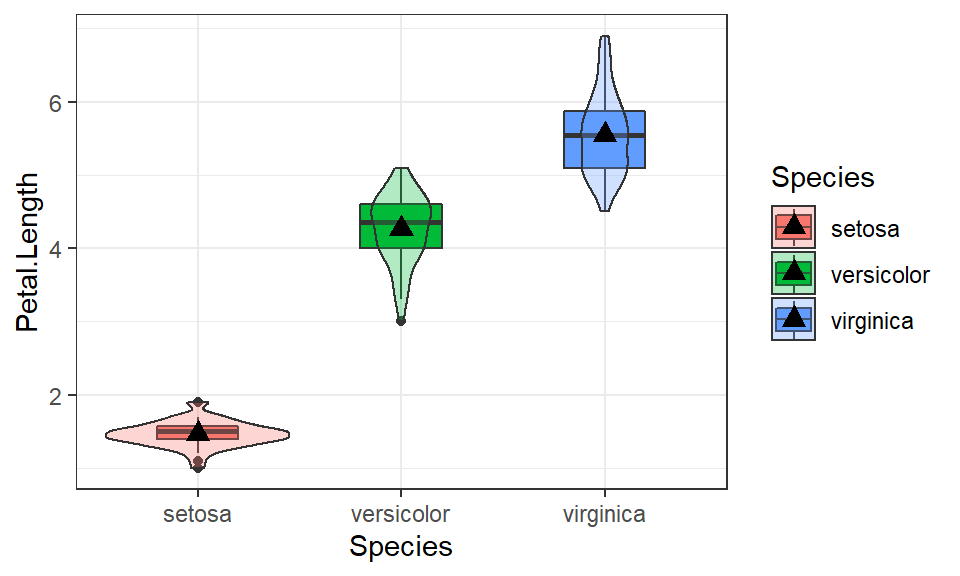

```r
ggplot(iris, aes(x=Species, y=Petal.Length, fill=Species)) +
  geom_boxplot(width=.4) + geom_violin(alpha=.3) +
  stat_summary(fun.y="mean", geom="point", size=3, pch=17,
    position=position_dodge(width=0.75)) + theme_bw()
```

3. **Write the relationship you want to examine in the form of a research question.**

Is there a relationship between the Petal length of an iris flower and the species of flower?

- Null Hypothesis: There is no relationship between Petal length and Species.
- Alternate Hypothesis: There is a relationship between petal length and Species.
4. **Perform an appropriate statistical analysis.**
   1. Let $\mu_{1}$ be the true mean petal length for *Setosa* Let $\mu_{2}$ be the true mean petal length for *Versicolor* Let $\mu_{3}$ be the true mean petal length for *Virginica*
   2. $H_{0}: \mu_{1} = \mu_{2} = \mu_{3}$  
      $H_{A}:$ At least one group mean is different.
   3. I will conduct an analysis of variance using ANOVA. The distribution of petal length looks approximately normal within each species group. We can assume that the group means are normally distributed due to the sample size within each group $n=50$ being large enough for the CLT to hold. The assumption of equal variances may be violated here; the sd of *setosa* is less than half that of the other two species.
   4. Reject the null, the p-value is <.0001.

```r
pander(summary(aov(Petal.Length ~ Species, data=iris)))
```

Analysis of Variance Model

|  | Df | Sum Sq | Mean Sq | F value | Pr(>F) |
| --- | --- | --- | --- | --- | --- |
| **Species** | 2 | 437.1 | 218.6 | 1180 | 2.857e-91 |
| **Residuals** | 147 | 27.22 | 0.1852 | NA | NA |

Since the ANOVA was significant, I need to conduct a post-hoc test to identify which pairs are different.

```r
TukeyHSD(aov(Petal.Length ~ Species, data=iris))
```

```
##   Tukey multiple comparisons of means
##     95% family-wise confidence level
##
## Fit: aov(formula = Petal.Length ~ Species, data = iris)
##
## $Species
##                       diff     lwr     upr p adj
## versicolor-setosa    2.798 2.59422 3.00178     0
## virginica-setosa     4.090 3.88622 4.29378     0
## virginica-versicolor 1.292 1.08822 1.49578     0
```

All pairs are significantly different from each other. The p-value for all post-hoc tests are all less than .0001.

*The code below is just an example of how to make a better looking table*

```r
kable(TukeyHSD(aov(Petal.Length ~ Species, data=iris))$Species, digits=3)
```

|  | diff | lwr | upr | p adj |
| --- | --- | --- | --- | --- |
| versicolor-setosa | 2.798 | 2.594 | 3.002 | 0 |
| virginica-setosa | 4.090 | 3.886 | 4.294 | 0 |
| virginica-versicolor | 1.292 | 1.088 | 1.496 | 0 |

5. **Write a conclusion in context of the problem.**

There is sufficient evidence to conclude that the average petal length of an iris flower is associated with the species of the Iris (p<.0001). Specifically the length of the petal for species *Virginica* is 4.1 (95% CI 3.9, 4.3) cm longer than *Setosa*, and 1.3 (95%CI 1.1, 1.5) cm longer than *Versicolor*. *Versicolor* is also significantly longer than *Setosa* (2.8, 95% CI 2.6, 3.0) cm. All pairwise comparisons were significant at the .0001 level.

# (B ~ C) Chi-Square Test of Association

A chi square ($\chi^{2}$) test of association (independence) compares frequencies of one categorical variable for different values of a second categorical variable. The null hypothesis is that the relative proportions (values) of one variable are “independent” of the second variable; in other words, the proportions of one variable are the same for different values of the second variable. The alternate hypothesis is that the relative proportions of one variable are associated with the second variable

Although it is possible to run large chi square tables (i.e., 5 x 5, 4 x 6, etc.), the test is most easily interpretable when your response variable has only 2 levels. Therefore, if your chosen response variable has more than 2 levels, you must collapse it down to two levels like you did with the bivariate graphing assignment

**Post hoc Analysis**

The `RVAideMemoire` package provides the `fisher.multcomp` function to conduct post-hoc pairwise comparisons after a significant chi-squared test of association. See the [RVAideMemoire Package reference](https://rdrr.io/cran/RVAideMemoire/) for more information on how to use this function. There are many methods to control for multiple comparisons, the default is to use the *fdr* or “false discovery rate”.

##### Example

1. **Identify response and explanatory variables**
- Ever smoked an entire cigarette in their life = binary explanatory variable (variable `eversmoke_c`)
- General Health = categorical response variable (variable `genhealth`)
2. **Visualize and summarise bivariate relationship**

```r
crosstab.smoke.genhealth <- table(addhealth$eversmoke_c, addhealth$genhealth)
kable(crosstab.smoke.genhealth)
```

|  | Excellent | Very good | Good | Fair | Poor |
| --- | --- | --- | --- | --- | --- |
| Never Smoked | 403 | 694 | 525 | 136 | 15 |
| Smoked at least once | 573 | 1265 | 1154 | 292 | 40 |

```r
proptab.smoke.genhealth <- prop.table(crosstab.smoke.genhealth, margin=2)
kable(proptab.smoke.genhealth, digits=3)
```

|  | Excellent | Very good | Good | Fair | Poor |
| --- | --- | --- | --- | --- | --- |
| Never Smoked | 0.413 | 0.354 | 0.313 | 0.318 | 0.273 |
| Smoked at least once | 0.587 | 0.646 | 0.687 | 0.682 | 0.727 |

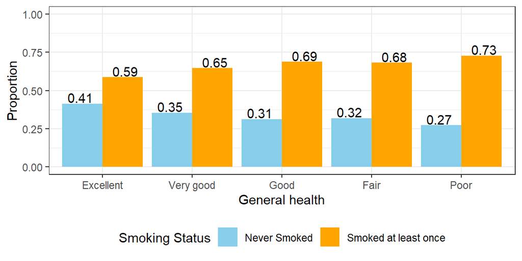

```r
plot.crostab <- data.frame(proptab.smoke.genhealth)

ggplot(plot.crostab, aes(x=Var2, y=Freq, fill=Var1)) +
        geom_col(position = position_dodge()) + theme_bw() +
        geom_text(aes(y=Freq+.04, label=round(Freq,2)), position = position_dodge(width=1)) +
        labs(x="General health", y="Proportion") +
        scale_fill_manual(name="Smoking Status", values=c("skyblue", "orange")) +
        scale_y_continuous(limits=c(0,1)) +
        theme(legend.position="bottom")
```

The percentage of smokers seems to increase as the general health status decreases. Almost three-quarters (73%) of those reporting poor health have smoked an entire cigarette at least once in their life compared to 59% of those reporting excellent health.

If your categorical variable is binary as in this example, what we’re really interested in is the proportion of “yes” responses (here it’s ever smoked). This is the group that we identify specifically in our hypothesis generation. To simplify the graph then, you can plot only the % of the group that you’re interested in. Again, this only holds for binary categorical variables since within each categorical grouping variable (along the x axis) the proportions of the outcome variable will sum to 1. Note that I have to better specify what the proportion is along the Y axis now (i.e. *proportion of those who have ever smoked* instead of simply *proportion*).

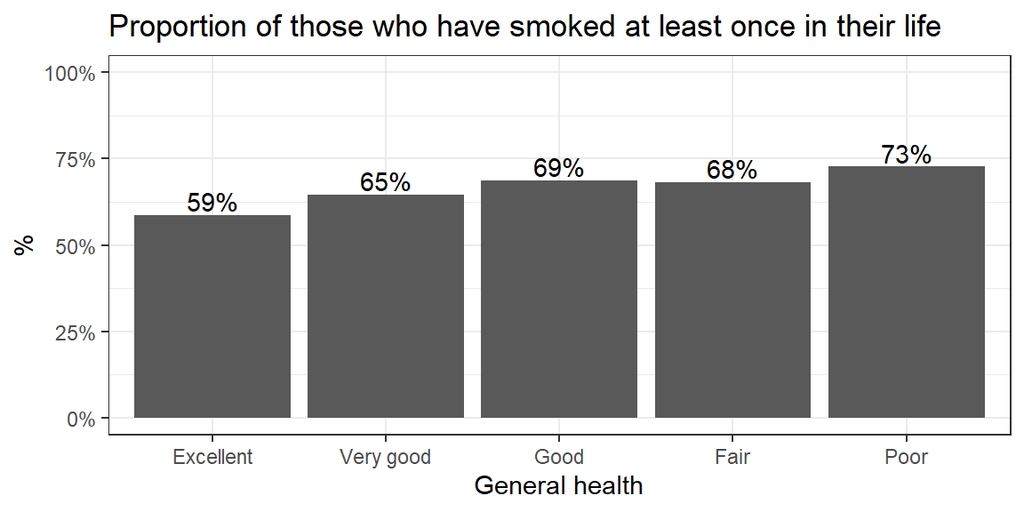

```r
plot.crostab.smoke <- filter(plot.crostab, Var1=="Smoked at least once")

ggplot(plot.crostab.smoke, aes(x=Var2, y=Freq)) +
        geom_col(position = position_dodge()) + theme_bw() +
        geom_text(aes(y=Freq+.04, label=paste0(round(Freq,2)*100, "%")),
                      position = position_dodge(width=1)) +
        labs(x="General health", y="%",
             title="Proportion of those who have smoked at least once in their life") +
        scale_y_continuous(limits=c(0,1), labels=percent)
```

3. **Write the relationship you want to examine in the form of a research question.**

Is the proportion of those who have ever smoked equal across all levels of general health?

- Null Hypothesis: The proportion in each general health category is the same.
- Alternate Hypothesis: At least one proportion is different.
4. **Perform an appropriate statistical analysis.**
   1. Let $p_{i}$ be the true proportion of those who have ever smoked in general health category $i$.
   2. $H_{0}: p_{1} = p_{2} = p_{3}$  
      $H_{A}:$ At least one proportion is different.
   3. I will conduct a Chi-squared test of association. There is at least 5 observations in each combination of smoking status and general health.
   4. Reject the null, the p-value is <.0001.

```r
chisq.test(addhealth$genhealth, addhealth$eversmoke_c)
```

```
##
##  Pearson's Chi-squared test
##
## data:  addhealth$genhealth and addhealth$eversmoke_c
## X-squared = 30.795, df = 4, p-value = 3.371e-06
```

Since the test was significant, I will conduct a post-hoc test to identify which pairs are different.

```r
RVAideMemoire::fisher.multcomp(table(addhealth$genhealth, addhealth$eversmoke_c), p.method="fdr")
```

```
##
##         Pairwise comparisons using Fisher's exact test for count data
##
## data:  table(addhealth$genhealth,addhealth$eversmoke_c)
##
##           Excellent Very good   Good   Fair
## Very good 6.965e-03         -      -      -
## Good      2.047e-06   0.02062      -      -
## Fair      4.163e-03   0.26903 0.8611      -
## Poor      9.495e-02   0.36087 0.7303 0.6753
##
## P value adjustment method: fdr
```

*Hint: Put the categorical variable first in the table*

# (Q~Q) Correlation analysis

A correlation coefficient assesses the degree of linear relationship between two variables. It ranges from +1 to -1. A correlation of +1 means that there is a perfect, positive, linear relationship between the two variables. A correlation of -1 means there is a perfect, negative linear relationship between the two variables. In both cases, knowing the value of one variable, you can perfectly predict the value of the second.

Explain your results for each correlation in terms of strength (actual number value) and direction (using the sign and scatter plot) within the context of the relationship you are examining. Then discuss the r-squared value. Please put each explanation after the appropriate results.

Below are rough estimates for interpreting strengths of correlations (to be used in write up): If the magnitude of $r$ is …

> - .70 and larger Very strong relationship
> - .40 to .69 Strong relationship
> - .30 to .39 Moderate relationship
> - .20 to .29 Weak relationship
> - .19 and below No or negligible relationship

**Correlation as a measure of model fit.** When we square $r$ (i.e. $R^{2}$), it tells us what proportion of the variability in one variable that is described by variation in the second variable.

##### Example

1. **Identify response and explanatory variables**
- Sepal Length = quantitative explanatory variable (variable `Sepal.Length`)
- Petal Length = categorical response variable (variable `Petal.Length`)
2. **Visualize and summarise bivariate relationship**

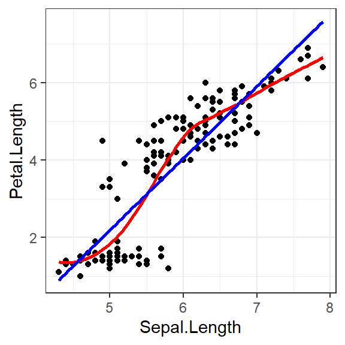

```r
ggplot(iris, aes(x=Sepal.Length, y=Petal.Length)) + geom_point() +
      geom_smooth(se=FALSE, col="red") +
      geom_smooth(method="lm", col="blue", se=FALSE) +
      theme_bw()
```

```r
cor(iris$Sepal.Length, iris$Petal.Length)
```

```
## [1] 0.8717538
```

3. **Write the relationship you want to examine in the form of a research question.**
- Null Hypothesis: There is no correlation between length of sepal and petal.
- Alternate Hypothesis: Sepal and petal lengths are correlated
4. **Perform an appropriate statistical analysis.**

   I. Let $\rho$ be the true correlation between sepal and petal length.
   2. $H_{0}: \rho=0$  
      $H_{A}: \rho \neq 0$
   3. Both variables are quantitative, a correlation analysis will be conducted.

```r
cor.test(iris$Petal.Length, iris$Sepal.Length)
```

```
##
##  Pearson's product-moment correlation
##
## data:  iris$Petal.Length and iris$Sepal.Length
## t = 21.646, df = 148, p-value < 2.2e-16
## alternative hypothesis: true correlation is not equal to 0
## 95 percent confidence interval:
##  0.8270363 0.9055080
## sample estimates:
##       cor
## 0.8717538
```

```
IV. Reject the null hypothesis: p-value for $\rho$ is <.0001.
```

5. **Write a conclusion in context of the problem.**

# (Q~Q) Linear Regression Analysis

Linear regression models can be used to evaluate whether there is a linear relationship between two numerical variables. When only one explanatory variable x is considered, this is termed simple linear regression (SLR). The basic idea of SLR is to use data to fit a straight line that relates the response Y to the predictor X. The mathematical relationship between x and y is written as

$$y_{i} \sim \beta_{0} + \beta_{1}x_{i} + \epsilon_{i} \qquad \epsilon_{i} \sim \mathcal{N}(0, \sigma^{2})$$

Using a sample of data we can calculate point estimates $b_{0}$ and $b_{1}$ to estimate the population parameter values $\beta_{0}$ and $\beta_{1}$ respectively. Calculating these estimates uses a procedure called Least Squares Regression.

A linear regression analysis tests the hypothesis that there is no linear relationship between x and y ($\beta_{1}=0$) versus there is a linear relationship ($\beta_{1} \neq 0$)

##### Example

1. **Identify response and explanatory variables**
- Sepal Length = quantitative explanatory variable (variable `Sepal.Length`)
- Petal Length = categorical response variable (variable `Petal.Length`)
2. **Visualize and summarise bivariate relationship**

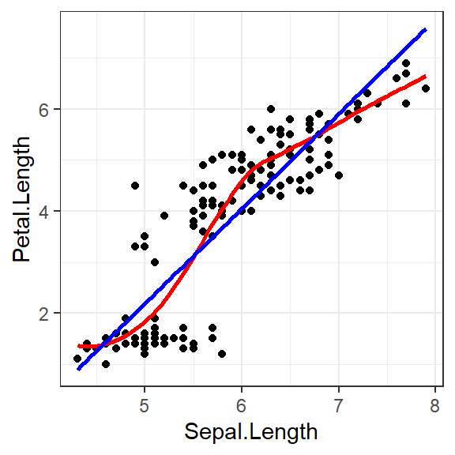

```r
ggplot(iris, aes(x=Sepal.Length, y=Petal.Length)) + geom_point() +
      geom_smooth(se=FALSE, col="red") +
      geom_smooth(method="lm", col="blue", se=FALSE) +
      theme_bw()
```

```r
cor(iris$Sepal.Length, iris$Petal.Length)
```

```
## [1] 0.8717538
```

3. **Write the relationship you want to examine in the form of a research question.**

Does the length of the flower’s sepal linearly correlate with the length of the flower’s petal?

- Null Hypothesis: There is no linear relationship between length of sepal and petal.
- Alternate Hypothesis: Sepal and petal lengths are linearly related.
4. **Perform an appropriate statistical analysis.**

   I. Let $\beta_{1}$ be the true measure of linear association between sepal and petal length.
   2. $H_{0}: \beta_{1}=0$  
      $H_{A}: \beta_{1} \neq 0$
   3. Both variables are quantitative, a linear regression analysis will be conducted. The first assumption that the relationship is linear is verified using the scatterplot in part 2. Further assumptions are that the residuals are normally distributed, centered around zero and have constant variance. All assumptions are checked after the model has been fit.
   4. Reject the null hypothesis: p-value for $\beta_{1}$ is <.0001.

```r
iris.linear.model <- lm(Petal.Length ~ Sepal.Length, data=iris)
pander(summary(iris.linear.model))
```

|  | Estimate | Std. Error | t value | Pr(>\|t\|) |
| --- | --- | --- | --- | --- |
| **(Intercept)** | -7.101 | 0.5067 | -14.02 | 6.134e-29 |
| **Sepal.Length** | 1.858 | 0.08586 | 21.65 | 1.039e-47 |

Fitting linear model: Petal.Length ~ Sepal.Length

| Observations | Residual Std. Error | $R^2$ | Adjusted $R^2$ |
| --- | --- | --- | --- |
| 150 | 0.8678 | 0.76 | 0.7583 |

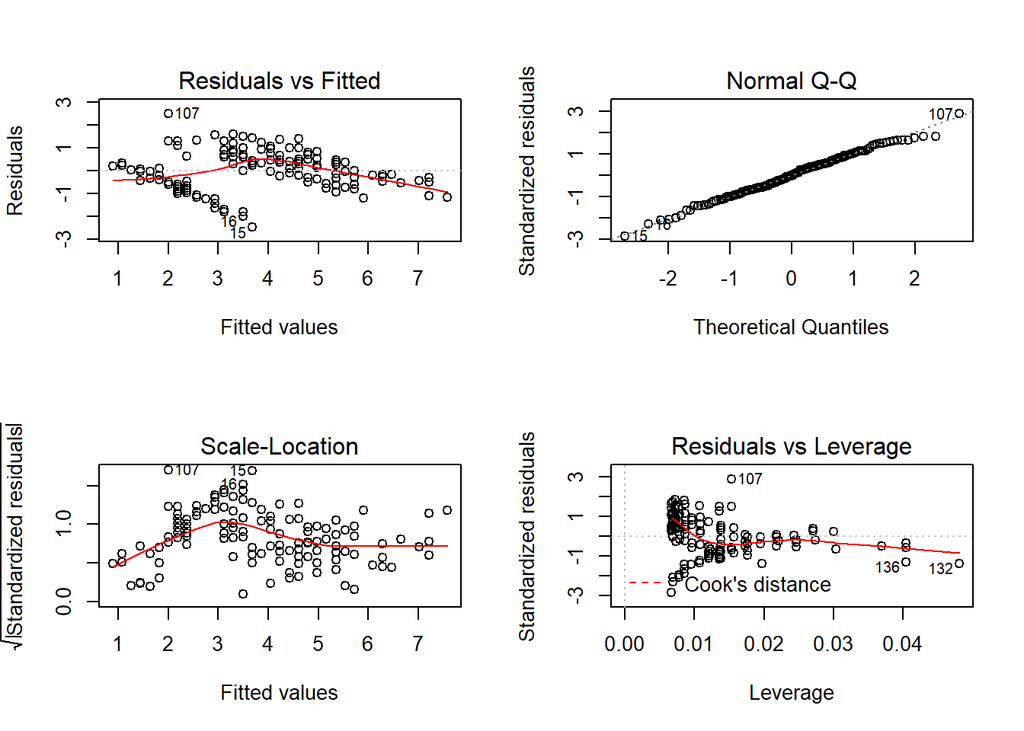

```r
par(mfrow=c(2,2))
plot(iris.linear.model)
```

The model assumptions appear to be upheld. The normal Q-Q plot indicate that the residuals are normally distributed, the residuals vs fitted plot indicate that the residuals are centered around zero. There might be a slight violation of the assumption of homoscedascitiy (constant variance), the variance of the residuals appears to decrease as the fitted values increase.

```r
pander(confint(iris.linear.model))
```

|  | 2.5 % | 97.5 % |
| --- | --- | --- |
| **(Intercept)** | -8.103 | -6.1 |
| **Sepal.Length** | 1.689 | 2.028 |

5. **Write a conclusion in context of the problem.**

The length of a petal and sepal on an iris flower are linearly correlated. For every 1 cm longer the sepal of the flower is, the petal length is increased by 1.85cm (95% CI 1.69, 2.03, p<.0001).